# Chapter-18-ExerciseSolutions

2022-10-22

# Chapter 18: Regression Models and Evaluation

## Exercises solutions

### Exercise 1

Inspect the coefficients of the linear model trained on the polynomial features. Find the coefficient responsible for the large error and explain why it has an especially strong effect on the polynomial features.

For this exercise we will use the diabetes dataset: this dataset has 10 attributes about a patient as features and disease progression after a year as the target. The dataset contains data for 442 patients.

```r
dt <- diabetes %>% data.table()
y <- dt[["target"]]

train_test_index <- caret::createDataPartition(y, times = 1, p = 0.7)

train <- dt[ train_test_index$Resample1,]
test_init  <- dt[-train_test_index$Resample1,]

y_test <- test_init[["target"]]

test_val_index <- caret::createDataPartition(y_test, times = 1, p = 0.5)

test <- test_init[ test_val_index$Resample1,]
validation  <- test_init[-test_val_index$Resample1,]

base::rm(train_test_index,test_val_index, test_init, y_test, y, dt)
```

We stadardise the features:

```r
train_sc_mat <- scale(train[, !c("target")])

test_sc_mat <- scale(test[, !c("target")])

val_sc_mat <- scale(validation[, !c("target")])
```

We process the data to a second polynomial degree, so that we have more features that relate to the input in different ways:

```r
train_sc_poly <-
  cbind(train_sc_mat, polym(train_sc_mat, degree = 2, raw = TRUE)) %>%
  data.table() %>%
  .[, target := train$target]

test_sc_poly <-
  cbind(test_sc_mat, polym(test_sc_mat, degree = 2, raw = TRUE)) %>%
  data.table() %>%
  .[, target := test$target]

val_sc_poly <-
  cbind(val_sc_mat, polym(val_sc_mat, degree = 2, raw = TRUE)) %>%
  data.table() %>%
  .[, target := validation$target]
```

Model Training

With the available programming libraries in Python or R, linear regression is very easy to use and just like the previous models for classification we use their fit and predict methods:

```r
lm_dia = lm(target ~ ., data = train_sc_poly)

#lm_dia = caret::train(target ~ ., method='lm', data = train_sc_poly)

train_pred = predict(lm_dia, newdata = train_sc_poly)
val_pred = predict(lm_dia, newdata = test_sc_poly)
test_pred = predict(lm_dia, newdata = val_sc_poly)

print(paste("Train RMSE:", rmse(train$target, train_pred)))
```

```
## [1] "Train RMSE: 48.3008766114807"
```

```r
print(paste("Test RMSE:", rmse(test$target, test_pred)))
```

```
## [1] "Test RMSE: 165.811915227792"
```

```r
print(paste("Validation RMSE:", rmse(validation$target, val_pred)))
```

```
## [1] "Validation RMSE: 98.091448726514"
```

Model Evaluation

We can retrieve the non-zero polynamial features and see their weight:

```r
data.table(coef = lm_dia$coefficients,
             feature = names(lm_dia$coefficients)) %>%
  na.omit() %>%
  .[order(-abs(coef))]
```

```
##              coef               feature
##  1: -1875.2597223                    s1
##  2:  1661.0477854                    s2
##  3:   681.9569295                    s3
##  4:   642.7869236                    s5
##  5:  -212.7336503 `0.0.0.0.1.1.0.0.0.0`
##  6:   187.5823261 `0.0.0.0.2.0.0.0.0.0`
##  7:  -145.2912743 `0.0.0.0.0.1.0.0.1.0`
##  8:  -131.4797112 `0.0.0.0.1.0.1.0.0.0`
##  9:   118.3442581 `0.0.0.0.1.0.0.0.1.0`
## 10:    92.3382399 `0.0.0.0.0.0.0.0.2.0`
## 11:   -67.1766495 `0.0.0.0.1.0.0.1.0.0`
## 12:    65.4025161 `0.0.0.0.0.1.1.0.0.0`
## 13:   -51.8492564 `0.0.0.0.0.0.1.0.1.0`
## 14:   -51.7970910 `1.0.0.0.1.0.0.0.0.0`
```

[output cut: 52 more lines]

Standard solutions to this problem are regularizations methods such as L1 (Lasso) and L2 (Ridge) which add a penalty term to the model’s cost function proportional to the size of the coefficients, hence penalizing large values. Namely, the L1 regularization adds a penalty equal to the absolute value of the magnitude of the coefficients, whereas the L2 regularization one equal to the square of the magnitude. These techniques can help reduce variance in the model and yield smaller generalization errors.

Note: R automatically NA’s exploding variables so they are not visible in the output.

### Exercise 2

Implement a grid search for the alpha parameter of a linear regression on the train/validation split with the poly 2 features of the diabetes data:

Note: In R alpha is defined as: The elastic net mixing parameter, with 0≤α≤1. More info in ?glmnet

```r
training_curve <- data.table()

for (a in seq(0,1, length.out = 100)) {

  # loop_lm_dia = caret::train(target ~ ., method = "glmnet", data = train,
  #                           tuneGrid = expand.grid(alpha = a, lambda = 1))
  #
  # fitted <- predict(loop_lm_dia)
  # predicted <- predict(loop_lm_dia, validation)

  loop_lm_dia = glmnet::glmnet(as.matrix(train[, !c("target")]), as.matrix(train_sc_poly[, .(target)]), alpha = a, lambda = 1)

  fitted <- predict(loop_lm_dia, as.matrix(train[, !c("target")]))
  predicted <- predict(loop_lm_dia, as.matrix(validation[, !c("target")]))

  loop_train_rmse <- rmse(train$target, fitted)
  loop_val_rmse <- rmse(validation$target, predicted)

  training_curve <- rbind(training_curve, data.table(alpha = a,  train_rmse = loop_train_rmse, val_rmse = loop_val_rmse))
}

head(training_curve)
```

```
##         alpha train_rmse val_rmse
## 1: 0.00000000   54.21857 52.40327
## 2: 0.01010101   54.22138 52.40716
## 3: 0.02020202   54.22409 52.41088
## 4: 0.03030303   54.22704 52.41498
## 5: 0.04040404   54.23007 52.41918
## 6: 0.05050505   54.23317 52.42350
```

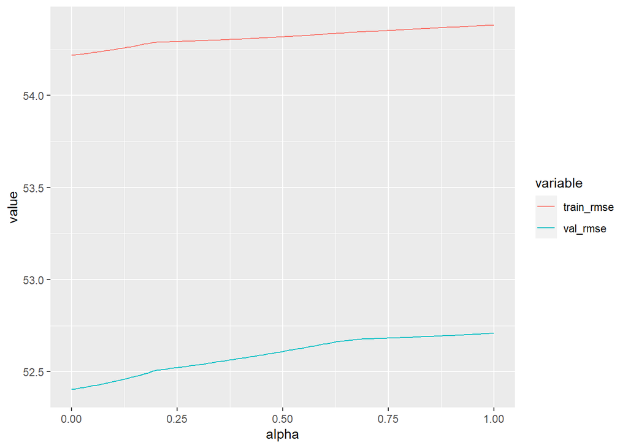

```r
data.table::melt(training_curve, "alpha", c("train_rmse", "val_rmse")) %>%
 ggplot() +
  geom_line(aes(alpha, value,  color = variable))
```

### Exercise 3

Implement a grid search for the alpha parameter of a linear regression using cross validation with the poly 2 features of the diabetes data. Use the Scikit-Learn class GridSearchCV.

```r
fitControl <- trainControl(method = "cv", number = 5)


training_curve_cv <- data.table()

for (a in seq(0,1, length.out = 100)) {

  loop_lm_dia = caret::train(target ~ ., method = "glmnet", data = train,
                             trControl = fitControl,
                            tuneGrid = expand.grid(alpha = a, lambda = 1))

  fitted <- predict(loop_lm_dia)
  predicted <- predict(loop_lm_dia, validation)

  loop_train_rmse <- rmse(train$target, fitted)
  loop_val_rmse <- rmse(validation$target, predicted)

  training_curve_cv <- rbind(training_curve_cv, data.table(alpha = a,  train_rmse = loop_train_rmse, val_rmse = loop_val_rmse))
}

head(training_curve_cv)
```

```
##         alpha train_rmse val_rmse
## 1: 0.00000000   54.34569 52.42553
## 2: 0.01010101   54.22125 52.40820
## 3: 0.02020202   54.22404 52.41207
## 4: 0.03030303   54.22705 52.41123
## 5: 0.04040404   54.23018 52.41552
## 6: 0.05050505   54.23331 52.41989
```

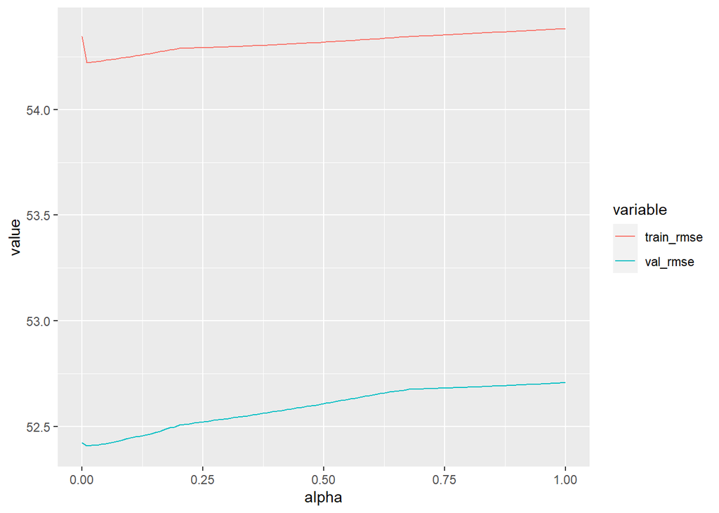

```r
data.table::melt(training_curve_cv, "alpha", c("train_rmse", "val_rmse")) %>%
 ggplot() +
  geom_line(aes(alpha, value,  color = variable))
```

```r
head(training_curve_cv[order(-val_rmse)],1)
```

```
##    alpha train_rmse val_rmse
## 1:     1   54.38301 52.70822
```

### Exercise 4

Load the California Housing dataset (either with sklearn.datasets.fetch_california_housing or from here ) and predict the house price (as a regression). Use different models, expand the features, tune the hyper-parameters, select the best model and estimate its performance on new data. Justify the choices or methods and models.

```r
cali = readr::read_csv('../../data/diabetes.csv',
                           show_col_types = FALSE)

head(cali)
```

```
## # A tibble: 6 × 11
##        age     sex     bmi       bp       s1      s2       s3       s4       s5
##      <dbl>   <dbl>   <dbl>    <dbl>    <dbl>   <dbl>    <dbl>    <dbl>    <dbl>
## 1  0.0381   0.0507  0.0617  0.0219  -0.0442  -0.0348 -0.0434  -0.00259  0.0199
## 2 -0.00188 -0.0446 -0.0515 -0.0263  -0.00845 -0.0192  0.0744  -0.0395  -0.0683
## 3  0.0853   0.0507  0.0445 -0.00567 -0.0456  -0.0342 -0.0324  -0.00259  0.00286
## 4 -0.0891  -0.0446 -0.0116 -0.0367   0.0122   0.0250 -0.0360   0.0343   0.0227
## 5  0.00538 -0.0446 -0.0364  0.0219   0.00393  0.0156  0.00814 -0.00259 -0.0320
## 6 -0.0927  -0.0446 -0.0407 -0.0194  -0.0690  -0.0793  0.0413  -0.0764  -0.0412
## # … with 2 more variables: s6 <dbl>, target <dbl>
```

```r
dt <- cali %>% data.table()
y <- dt[["target"]]

train_test_index <- caret::createDataPartition(y, times = 1, p = 0.7)

train_cali <- dt[ train_test_index$Resample1,]
test_init  <- dt[-train_test_index$Resample1,]

y_test <- test_init[["target"]]

test_val_index <- caret::createDataPartition(y_test, times = 1, p = 0.5)

test_cali <- test_init[ test_val_index$Resample1,]
validation_cali  <- test_init[-test_val_index$Resample1,]

base::rm(train_test_index,test_val_index, test_init, y_test, y, dt)
```

```r
train_cali_sc <- data.table(scale(train_cali[, !c("target")]))[, target := train$target]

test_cali_sc <- data.table(scale(test_cali[, !c("target")]))[, target := test$target]

val_cali_sc <- data.table(scale(validation_cali[, !c("target")]))[, target := validation$target]
```

Models Training

Let us compare a few regression models:

```
Ordinary least squares (OLS)
Lasso
Ridge
Decision tree
Multi-layer perceptron (MLP)
```

We fit and train a “vanilla” version of the models on the data. No hyperparameters tuning, no expanded features, all very basic for now:

```r
fitControl <- trainControl(method = "none")

lm_cali = caret::train(target ~ ., method = "lm", data = train_cali_sc, trControl = fitControl)

lasso_cali = caret::train(target ~ ., method = "glmnet", data = train_cali_sc, trControl = fitControl,
                          tuneGrid = expand.grid(alpha = 1, lambda = 1))

ridge_cali = caret::train(target ~ ., method = "glmnet", data = train_cali_sc, trControl = fitControl,
                          tuneGrid = expand.grid(alpha = 0, lambda = 1))

dt_cali = caret::train(target ~ ., method = "rpart2", data = train_cali_sc, trControl = fitControl)

mlp_cali = caret::train(target ~ ., method = "mlp", data = train_cali_sc, trControl = fitControl)


print(paste("OLS (LM) RMSE: Train = ", round(rmse(train_cali_sc$target, predict(lm_cali)),2),
            "Test = ", round(rmse(test_cali_sc$target, predict(lm_cali, test_cali_sc)),2)))
```

```
## [1] "OLS (LM) RMSE: Train =  76.08 Test =  80.18"
```

```r
print(paste("Ridege RMSE: Train = ", round(rmse(train_cali_sc$target, predict(ridge_cali)),2),
            "Test = ", round(rmse(test_cali_sc$target, predict(ridge_cali, test_cali_sc)),2)))
```

```
## [1] "Ridege RMSE: Train =  76.13 Test =  80.02"
```

```r
print(paste("Lasso RMSE: Train = ", round(rmse(train_cali_sc$target, predict(lasso_cali)),2),
            "Test = ", round(rmse(test_cali_sc$target, predict(lasso_cali, test_cali_sc)),2)))
```

```
## [1] "Lasso RMSE: Train =  76.35 Test =  78.92"
```

```r
print(paste("Decision Tree RMSE: Train = ", round(rmse(train_cali_sc$target, predict(dt_cali)),2),
            "Test = ", round(rmse(test_cali_sc$target, predict(dt_cali, test_cali_sc)),2)))
```

```
## [1] "Decision Tree RMSE: Train =  75.55 Test =  78.6"
```

```r
print(paste("MLP RMSE: Train = ", round(rmse(train_cali_sc$target, predict(mlp_cali)),2),
            "Test = ", round(rmse(test_cali_sc$target, predict(mlp_cali, test_cali_sc)),2)))
```

```
## [1] "MLP RMSE: Train =  109.93 Test =  111.45"
```